# Running a Simulation with metaRVM

## Exploring the Results

The `metaRVM()` function returns a `MetaRVMResults` object with formatted, analysis-ready data. The results are formatted with calendar dates and demographic attributes, and stored in a data frame called results:

```r
# Look at the structure of formatted results
head(sim_out$results)
```

```
#>          date    age   race  zone disease_state        value instance
#>        <Date> <char> <char> <int>        <char>        <num>    <int>
#> 1: 2023-10-01   0-17      A    11             D 2.252583e-04        1
#> 2: 2023-10-01   0-17      A    11             E 1.365434e+01        1
#> 3: 2023-10-01   0-17      A    11             H 2.304447e-01        1
#> 4: 2023-10-01   0-17      A    11         I_all 2.742619e+01        1
#> 5: 2023-10-01   0-17      A    11       I_asymp 3.555784e-01        1
#> 6: 2023-10-01   0-17      A    11         I_eff 2.483657e+01        1
```

```r
# Check unique values for key variables
cat("Disease states:", paste(unique(sim_out$results$disease_state), collapse = ", "), "\n")
```

```
#> Disease states: D, E, H, I_all, I_asymp, I_eff, I_presymp, I_symp, P, R, S, S_alloc, S_eff_prod, S_src_int, V, V_alloc, V_src_int, cum_V, mob_pop, n_EI, n_EIpresymp, n_HD, n_HR, n_HRD, n_IasympR, n_IsympH, n_IsympR, n_IsympRH, n_RS, n_SE, n_SE_eff, n_SV, n_VE, n_VS, n_preIsymp, p_HRD, p_RS, p_SE,…
```

```r
cat("Date range:", paste(range(sim_out$results$date), collapse = " to "), "\n")
```

```
#> Date range: 2023-10-01 to 2024-02-27
```

### Data Subsetting and Filtering

The `subset_data()` method provides flexible filtering across all demographic and temporal dimensions. It returns an object of class `MetaRVMResults`.

```r
# Subset by single criteria
hospitalized_data <- sim_out$subset_data(disease_states = "H")
hospitalized_data$results
```

```
#>             date    age   race  zone disease_state      value instance
#>           <Date> <char> <char> <int>        <char>      <num>    <int>
#>    1: 2023-10-01   0-17      A    11             H  0.2304447        1
#>    2: 2023-10-01   0-17      A    22             H  0.2081436        1
#>    3: 2023-10-01   0-17      B    11             H  0.5203590        1
#>    4: 2023-10-01   0-17      B    22             H  0.3939861        1
#>    5: 2023-10-01   0-17      C    11             H  0.6244308        1
#>   ---
#> 3596: 2024-02-27    65+      B    22             H  1.2118718        1
#> 3597: 2024-02-27    65+      C    11             H  1.8624622        1
#> 3598: 2024-02-27    65+      C    22             H 10.2755842        1
#> 3599: 2024-02-27    65+      D    11             H  5.5349332        1
#> 3600: 2024-02-27    65+      D    22             H 12.4195984        1
```

```r
# Subset by multiple demographic categories
elderly_data <- sim_out$subset_data(
  age = c("65+"),
  disease_states = c("H", "D")
)
elderly_data$results
```

```
#>             date    age   race  zone disease_state        value instance
#>           <Date> <char> <char> <int>        <char>        <num>    <int>
#>    1: 2023-10-01    65+      A    11             D 2.179919e-05        1
#>    2: 2023-10-01    65+      A    11             H 2.230110e-02        1
#>    3: 2023-10-01    65+      A    22             D 1.453279e-05        1
#>    4: 2023-10-01    65+      A    22             H 1.486740e-02        1
#>    5: 2023-10-01    65+      B    11             D 8.719675e-05        1
#>   ---
#> 2396: 2024-02-27    65+      C    22             H 1.027558e+01        1
#> 2397: 2024-02-27    65+      D    11             D 3.831713e+01        1
#> 2398: 2024-02-27    65+      D    11             H 5.534933e+00        1
#> 2399: 2024-02-27    65+      D    22             D 8.635266e+01        1
#> 2400: 2024-02-27    65+      D    22             H 1.241960e+01        1
```

```r
# Specific date range
peak_period <- sim_out$subset_data(
  date_range = c(as.Date("2023-10-01"), as.Date("2023-12-31")),
  disease_states = "H"
)
peak_period$results
```

```
#>             date    age   race  zone disease_state      value instance
#>           <Date> <char> <char> <int>        <char>      <num>    <int>
#>    1: 2023-10-01   0-17      A    11             H  0.2304447        1
#>    2: 2023-10-01   0-17      A    22             H  0.2081436        1
#>    3: 2023-10-01   0-17      B    11             H  0.5203590        1
#>    4: 2023-10-01   0-17      B    22             H  0.3939861        1
#>    5: 2023-10-01   0-17      C    11             H  0.6244308        1
#>   ---
#> 2204: 2023-12-31    65+      B    22             H  7.0258803        1
#> 2205: 2023-12-31    65+      C    11             H  9.7905521        1
#> 2206: 2023-12-31    65+      C    22             H 52.9246952        1
#> 2207: 2023-12-31    65+      D    11             H 28.3456494        1
#> 2208: 2023-12-31    65+      D    22             H 63.2860726        1
```

# Specifying Disease Parameters via Distributions

`metaRVM` allows for disease parameters to be specified as distributions, which is useful for capturing uncertainty. When a parameter is defined by a distribution, each simulation instance will draw a new value from that distribution. For more details on the available distributions and their parameters, refer to the `yaml-configuration` vignette.

An example YAML file with parameter distributions is included in the package, `example_config_dist.yaml`. Here is its content:

```r
# Locate the example YAML configuration file with distributions
yaml_file_dist <- system.file("extdata", "example_config_dist.yaml", package = "MetaRVM")
```

```yaml
run_id: ExampleRun_Dist
population_data:
  initialization: population_init_n24.csv
  vaccination: vaccination_n24.csv
mixing_matrix:
  weekday_day: m_weekday_day.csv
  weekday_night: m_weekday_night.csv
  weekend_day: m_weekend_day.csv
  weekend_night: m_weekend_night.csv
disease_params:
  ts: 0.5
  ve:
    dist: uniform
    min: 0.3
    max: 0.5
  dv: 180
  dp: 1
  de: 3
  da:
    dist: uniform
    min: 4
    max: 6
  ds:
    dist: uniform
    min: 5
    max: 7
  dh:
    dist: lognormal
    mu: 2
    sd: 0.5
  dr: 180
  pea: 0.3
  psr: 0.95
  phr: 0.97
simulation_config:
  start_date: 01/01/2023 # m/d/Y
  length: 150
  nsim: 20 # Increased nsim for meaningful summary statistics
  nrep: 1
  simulation_mode: deterministic
  random_seed: 42
```

To run a simulation with this configuration, the file path is passed to `metaRVM`.

```r
# Run the simulation with the new configuration
sim_out_dist <- metaRVM(yaml_file_dist)
```

## Generating Summary Statistics across Demographics

The `MetaRVMResults` class provides basic summarization functionality across multiple instances of the simulation, when one or more disease parameters are specified via distribution, and there are more than one simulations per configurations. The `summarize` method generates output of class `MetaRVMSummary` which has a `plot` method available. After a simulation is run with parameter distributions, the `summarize` method can be used to inspect variability in the results.

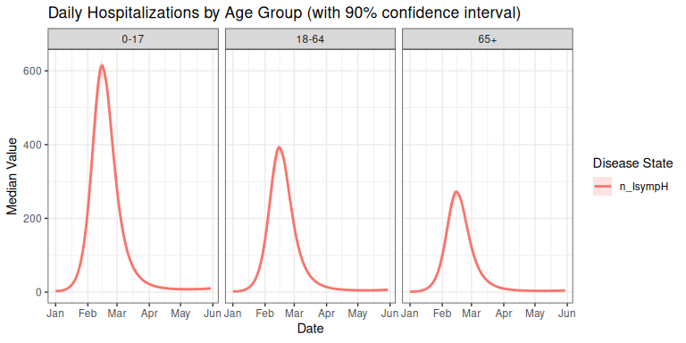

```r
library(ggplot2)

# Summarize hospitalizations by age group
hospital_summary_dist <- sim_out_dist$summarize(
  group_by = c("age"),
  disease_states = "n_IsympH",
  stats = c("median", "quantile"),
  quantiles = c(0.05, 0.95)
)

# Plot the summary
hospital_summary_dist$plot() + ggtitle("Daily Hospitalizations by Age Group (with 90% confidence interval)") + theme_bw()
```

# Running a Stochastic Simulation with Static Parameters

A stochastic simulation can also be run by setting `simulation_mode: stochastic`.

```r
# Locate the example YAML configuration file with distributions
yaml_file_stoch <- system.file("extdata", "example_config_stochastic.yaml", package = "MetaRVM")
```

```yaml
run_id: ExampleRun_Stochastic_Static
population_data:
  initialization: population_init_n24.csv
  vaccination: vaccination_n24.csv
mixing_matrix:
  weekday_day: m_weekday_day.csv
  weekday_night: m_weekday_night.csv
  weekend_day: m_weekend_day.csv
  weekend_night: m_weekend_night.csv
disease_params:
  ts: 0.5
  ve: 0.4
  dv: 180
  dp: 1
  de: 3
  da: 5
  ds: 6
  dh: 8
  dr: 180
  pea: 0.3
  psr: 0.95
  phr: 0.97
simulation_config:
  start_date: 01/01/2023 # m/d/Y
  length: 150
  nsim: 1
  nrep: 5
  simulation_mode: stochastic
  random_seed: 42
```

```r
sim_out_stoch <- metaRVM(yaml_file_stoch)
```

# Specifying Disease Parameters by Demographics

The disease parameters can also be specified for different demographic subgroups. These subgroup-specific parameters will override the global parameters. For more details, refer to the `yaml-configuration` vignette. An example YAML file is provided, `example_config_subgroup_dist.yaml`, that demonstrates this feature. It also includes parameters defined by distributions.

```r
# Locate the example YAML configuration file with subgroup parameters
yaml_file_subgroup <- system.file("extdata", "example_config_subgroup_dist.yaml", package = "MetaRVM")
```

```yaml
run_id: ExampleRun_Subgroup_Dist
population_data:
  initialization: population_init_n24.csv
  vaccination: vaccination_n24.csv
mixing_matrix:
  weekday_day: m_weekday_day.csv
  weekday_night: m_weekday_night.csv
  weekend_day: m_weekend_day.csv
  weekend_night: m_weekend_night.csv
disease_params:
  ts: 0.5
  ve:
    dist: uniform
    min: 0.3
    max: 0.5
  dv: 180
  dp: 1
  de: 3
  da: 5
  ds: 6
  dh:
    dist: lognormal
    mu: 2
    sd: 0.5
  dr: 180
  pea: 0.3
  psr: 0.95
  phr: 0.97
sub_disease_params:
    age:
      0-17:
        pea: 0.08
      18-64:
        ts: 0.6
      65+:
        # This fixed value will override the global lognormal distribution for dh
        dh: 10
        phr: 0.9227
simulation_config:
  start_date: 01/01/2023 # m/d/Y
  length: 150
  nsim: 20
  nrep: 1
  simulation_mode: deterministic
  random_seed: 42
```

Now, let’s run the simulation with this configuration.

```r
# Run the simulation with the subgroup configuration
sim_out_subgroup <- metaRVM(yaml_file_subgroup)
```

The results can now be plotted to evaluate the impact of subgroup-specific parameters. For example, the number of hospitalizations in the “65+” age group, which has a `dh` of 10, can be compared to other age groups that use the global `dh` drawn from a lognormal distribution.

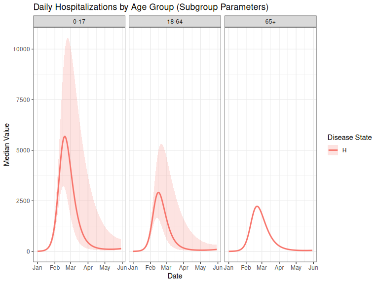

```r
# Summarize hospitalizations by age group
hospital_summary_subgroup <- sim_out_subgroup$summarize(
  group_by = c("age"),
  disease_states = "H",
  stats = c("median", "quantile"),
  quantiles = c(0.025, 0.975)
)

# Plot the summary
hospital_summary_subgroup$plot() + ggtitle("Daily Hospitalizations by Age Group (Subgroup Parameters)") + theme_bw()
```